# DATA ANALYSIS AND INSIGHTS REPORT ON WE_RATE_DOGS TWITTER ARCHIVE

WeRateDogs is a Twitter account that rates people's dogs with a humorous comments about the dog. These ratings almost always have a denominator of 10. The numerators, are almost always greater than 10. 11/10, 12/10, 13/10, etc. The following 3 insights or research questions were formulated from the dataset.

1. Which dog breed is the most likeable breed?
2. Which dog name is the most common ?
3. What is the user_performance of the user of the WeRate Dog Twitter account within the 3 years in the dataset?

### 1. Which dog breed is the most likeable breed?

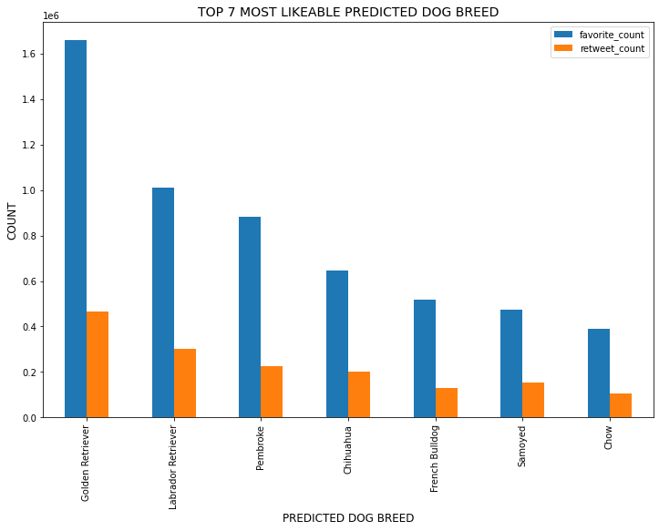

From the bar chart above, the Golden Retriever is the most likeable dog breed. it has the highest favourite count and retweet count. People liked the pictures of a Golden Retriever more than other breeds, hence, more retweets. this is can be due to certain characteristics of the breed such as their friendliness, tolerant attitude that makes them great family pets, and their intelligence makes them highly capable working dogs. The second dog breed on the list of the most likeable breed is the Labrador Retriever. Therefore, we can conclude that people tend to love the Retriever breed more based on their characteristics. Other breeds in the top 7 most likeable breed list are the Pembroke, the Chihuahua, the French Bulldog, the Samoyed and the Chow in descending order of likeness.

### 2. Which dog name is the most common?

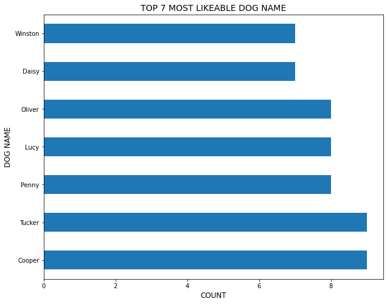

From the bar chart above, the most common or popular dog names among dog owners are Tucker and Cooper Other common dog names in the top 7 most likeable dog name lists are Penny, Lucy, Oliver, Daisy, and Winston in descending order.

### 3. What is the user_performance of the user of the WeRate Dog Twitter account within the 3 years in the dataset?

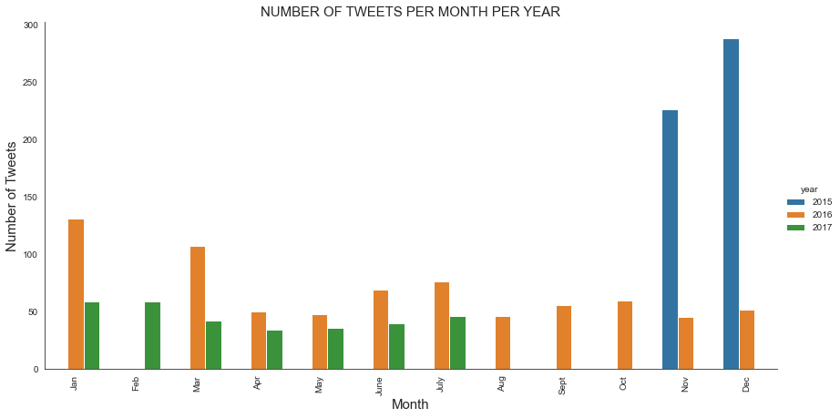

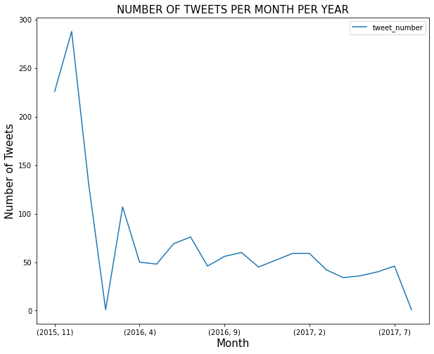

## CORRELATION BETWEEN VARIABLES

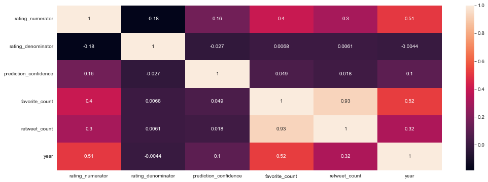

The correlation coefficients in the heatmap above are indicators of the strength of the linear relationship between two different variables, x and y. A correlation of -1.0 indicates a perfect negative correlation, and a correlation of 1.0 indicates a perfect positive correlation. If the correlation coefficient is greater than zero, it is a positive relationship. Conversely, if the value is less than zero, it is a negative relationship. A value of zero indicates no relationship between the two variables x and y. The analysis and visualization help to have a clearer view of the dataset. We were able to know the type of breed people love the most and the likely names people give their dogs and many other insights.